# STAT 302 SPR2020 Lecture 11

Sheridan Grant

May 4, 2020

## Preliminaries

```r
sat <- read.csv('../data/sat.csv')
colnames(sat)
```

```
## [1] "ï..sex" "SATV"   "SATM"   "SATSum" "HSGPA"  "FYGPA"
```

```r
colnames(sat)[1] <- 'sex'
sat$sex <- sat$sex - 1  # 0/1 is conventional, data gives 1/2
n <- dim(sat)[1]
```

## Factors

```r
sat$fakeSex <- sample(c('female', 'male', 'other/no response'), n, replace = T)
levels(sat$fakeSex)
```

[output not shown]

```r
sat$fakeSex <- as.factor(sat$fakeSex)
levels(sat$fakeSex)
```

```
## [1] "female"            "male"              "other/no response"
```

```r
lm(FYGPA ~ HSGPA + fakeSex, data = sat)
```

```
##
## Call:
## lm(formula = FYGPA ~ HSGPA + fakeSex, data = sat)
##
## Coefficients:
##              (Intercept)                     HSGPA               fakeSexmale
##                 0.081104                  0.741125                 -0.003988
## fakeSexother/no response
##                 0.052809
```

```r
# sat$fakeSex <- as.factor(sat$fakeSex, levels = c('male', 'female', 'other/no response'))
sat$fakeSex <- factor(sat$fakeSex, levels = c('male', 'female', 'other/no response'))
lm(FYGPA ~ HSGPA + fakeSex, data = sat)
```

```
##
## Call:
## lm(formula = FYGPA ~ HSGPA + fakeSex, data = sat)
##
## Coefficients:
##              (Intercept)                     HSGPA             fakeSexfemale
##                 0.077116                  0.741125                  0.003988
## fakeSexother/no response
##                 0.056797
```

## Prediction vs. Fit

```r
satMod1 <- lm(FYGPA ~ HSGPA, data = sat)
sse1 <- sum((sat$FYGPA - predict(satMod1))^2)
```

SSE measures *goodness of fit*, how well the model fits the data it was fit to.

Let’s improve our goodness of fit, shall we?

```r
nonsense <- matrix(rnorm(n*(n-2)), n, n-2)
nonsenseData <- data.frame(cbind(FYGPA = sat$FYGPA, HSGPA = sat$HSGPA, nonsense))
satMod2 <- lm(FYGPA ~ HSGPA + V3, data = nonsenseData)
cat('Old SSE:', sse1, '\n',
    'SSE with nonsense covariate included:',
    sum((sat$FYGPA - predict(satMod2))^2), '\n')
```

```
## Old SSE: 386.3839
##  SSE with nonsense covariate included: 386.3793
```

```r
satMod3 <- lm(FYGPA ~ ., data = nonsenseData[,1:502])

cat('Old SSE:', sse1, '\n',
    'SSE with 500 nonsense covariates included:',
    sum((sat$FYGPA - predict(satMod3))^2), '\n')
```

```
## Old SSE: 386.3839
##  SSE with 500 nonsense covariates included: 206.4906
```

```r
satMod4 <- lm(FYGPA ~ ., data = nonsenseData)
cat('Old SSE:', sse1, '\n',
    'SSE with 998 nonsense covariates included:',
    sum((sat$FYGPA - predict(satMod4))^2), '\n')
```

```
## Old SSE: 386.3839
##  SSE with 998 nonsense covariates included: 1.49979e-23
```

Something isn’t right.

### Degrees of Freedom

```r
cat('Residual standard error from model:', sigma(satMod1), '\n',
    'By hand:', sqrt(sse1/(n-length(coef(satMod1)))), '\n')
```

```
## Residual standard error from model: 0.6222204
##  By hand: 0.6222204
```

```r
cat('Old sigma-hat:', sigma(satMod1), '\n',
    'sigma-hat with nonsense covariate included:', sigma(satMod2), '\n')
```

```
## Old sigma-hat: 0.6222204
##  sigma-hat with nonsense covariate included: 0.6225287
```

```r
cat('Old sigma-hat:', sigma(satMod1), '\n',
    'sigma-hat with 500 nonsense covariates included:', sigma(satMod3), '\n')
```

```
## Old sigma-hat: 0.6222204
##  sigma-hat with 500 nonsense covariates included: 0.6439253
```

```r
cat('Old sigma-hat:', sigma(satMod1), '\n',
    'sigma-hat with 998 nonsense covariates included:', sigma(satMod4), '\n')  # div 0
```

```
## Old sigma-hat: 0.6222204
##  sigma-hat with 998 nonsense covariates included: NaN
```

Residual standard error (estimated std. dev., sigma-hat) estimates the standard deviation of the residual $\epsilon$. In normalizing by sample size, it divides by degrees of freedom, not sample size. $df = n - \text{# model parameters}$. The more parameters you estimate, the smaller the denominator and sigma-hat is inflated.

### Polynomials

Our clever trick–broken! Let’s try another.

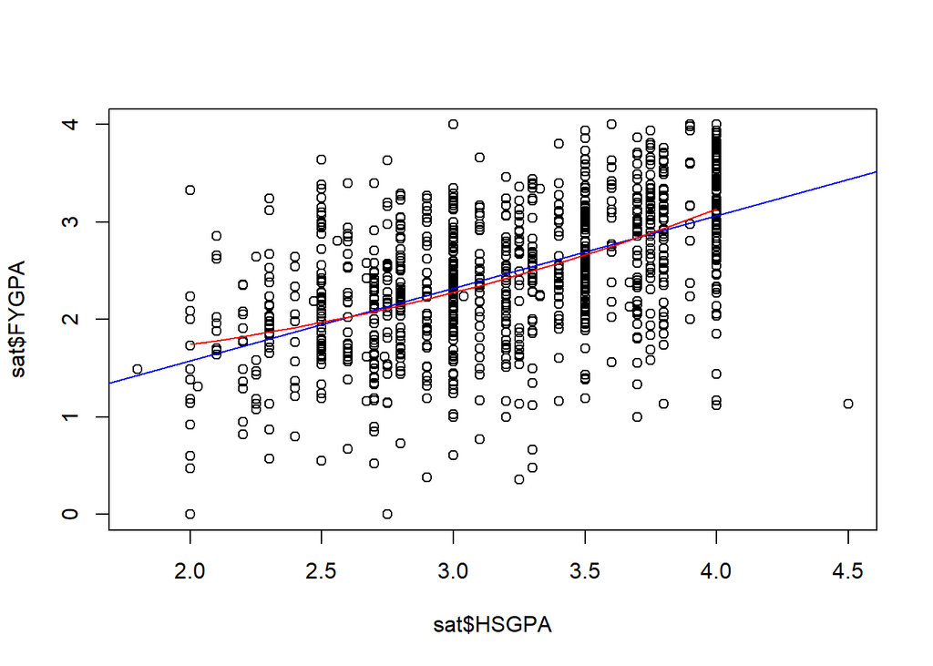

```r
satMod5 <- lm(FYGPA ~ HSGPA + I(HSGPA^2), data = sat)

plot(sat$HSGPA, sat$FYGPA)
abline(satMod1, col = 'blue')
lines(seq(2,4,.1), cbind(rep(1,21), seq(2,4,.1), seq(2,4,.1)^2)%*%coef(satMod5), col = 'red')
```

```r
cat('Old sigma-hat:', sigma(satMod1), '\n',
    'sigma-hat with quadratic term included:', sigma(satMod5), '\n')
```

```
## Old sigma-hat: 0.6222204
##  sigma-hat with quadratic term included: 0.6205632
```

```r
satMod6 <- lm(FYGPA ~ poly(HSGPA, 20), data = sat)

cat('Old sigma-hat:', sigma(satMod1), '\n',
    'sigma-hat with polynomial of order 20:', sigma(satMod6), '\n')
```

```
## Old sigma-hat: 0.6222204
##  sigma-hat with polynomial of order 20: 0.6132228
```

### Prediction

Split the data into train (we train, or fit, the model to this data) and test (we test the model’s predictive power on these data):

```r
indices <- sample(1000)
trainIndices <- indices[1:500]
testIndices <- indices[501:1000]
train <- nonsenseData[trainIndices,]
test <- nonsenseData[testIndices,]
```

```r
satMod1train <- lm(FYGPA ~ HSGPA, data = train)
sqrt(sum((train$FYGPA - predict(satMod1train, train))^2)/500)
```

```
## [1] 0.6352604
```

```r
sqrt(sum((test$FYGPA - predict(satMod1train, test))^2)/500)
```

```
## [1] 0.608939
```

Same thing for the model with tons of nonsense covariates. The training error is artificially low without the df correction, but the test error is higher than even the df-corrected error, because the nonsense covariates provide no predictive power–in fact, they *hurt* predictive power!

```r
satMod3train <- lm(FYGPA ~ ., data = train[,1:252])
summary(satMod3train)
```

```
##
## Call:
## lm(formula = FYGPA ~ ., data = train[, 1:252])
##
## Residuals:
##      Min       1Q   Median       3Q      Max
## -1.53178 -0.30271  0.01985  0.29197  1.22971
##
## Coefficients:
##               Estimate Std. Error t value Pr(>|t|)
## (Intercept)  0.0158164  0.2307646   0.069  0.94541
## HSGPA        0.7553888  0.0710417  10.633  < 2e-16 ***
## V3          -0.0006562  0.0395077  -0.017  0.98676
## V4           0.0089240  0.0414575   0.215  0.82974
## V5          -0.0356836  0.0409952  -0.870  0.38491
## V6           0.0747891  0.0416790   1.794  0.07397 .
## V7          -0.0622868  0.0415008  -1.501  0.13466
## V8           0.0300954  0.0406095   0.741  0.45934
## V9          -0.0805141  0.0388115  -2.074  0.03907 *
## V10          0.0419559  0.0382576   1.097  0.27385
## V11         -0.0580766  0.0421261  -1.379  0.16925
## V12          0.0240604  0.0385799   0.624  0.53343
## V13          0.0509567  0.0384582   1.325  0.18639
## V14         -0.0432835  0.0415836  -1.041  0.29895
## V15         -0.0533487  0.0414977  -1.286  0.19979
## V16          0.0537175  0.0387366   1.387  0.16677
## V17         -0.0194388  0.0384259  -0.506  0.61339
## V18         -0.0474335  0.0386885  -1.226  0.22135
## V19         -0.0127767  0.0404270  -0.316  0.75224
## V20         -0.0073184  0.0382708  -0.191  0.84850
## V21         -0.0230068  0.0400116  -0.575  0.56581
## V22          0.0173341  0.0404762   0.428  0.66884
## V23          0.0736723  0.0385849   1.909  0.05737 .
## V24         -0.0368480  0.0396117  -0.930  0.35316
## V25          0.1201161  0.0434312   2.766  0.00611 **
## V26         -0.0401590  0.0384457  -1.045  0.29724
## V27         -0.0173598  0.0397587  -0.437  0.66276
## V28         -0.0410622  0.0391379  -1.049  0.29512
## V29         -0.0197423  0.0396730  -0.498  0.61919
## V30          0.0078147  0.0370714   0.211  0.83322
```

[output cut: 213 more lines]

```
## V244        -0.0504948  0.0398161  -1.268  0.20592
## V245         0.0127973  0.0412398   0.310  0.75658
## V246        -0.0002923  0.0398267  -0.007  0.99415
## V247        -0.0230013  0.0418687  -0.549  0.58325
## V248         0.0375843  0.0417211   0.901  0.36854
## V249         0.0202445  0.0395959   0.511  0.60961
## V250         0.0316715  0.0378094   0.838  0.40303
## V251        -0.0711189  0.0388207  -1.832  0.06815 .
## V252        -0.0417906  0.0407695  -1.025  0.30634
## ---
## Signif. codes:  0 '***' 0.001 '**' 0.01 '*' 0.05 '.' 0.1 ' ' 1
##
## Residual standard error: 0.6306 on 248 degrees of freedom
## Multiple R-squared:  0.6617, Adjusted R-squared:  0.3194
## F-statistic: 1.933 on 251 and 248 DF,  p-value: 1.305e-07
```

```r
sqrt(sum((train$FYGPA - predict(satMod3train, train))^2)/500)
```

```
## [1] 0.444135
```

```r
sqrt(sum((train$FYGPA - predict(satMod3train, train))^2)/(500-252))  # df correction
```

```
## [1] 0.6306294
```

```r
sqrt(sum((test$FYGPA - predict(satMod3train, test))^2)/500)
```

```
## [1] 0.9111659
```